# Evaluation of the Performance of Community Detection Algorithms of benchmark networks

Fabio Morea

2023-05-19

Abstract

This notebook compares the performance of several community detection methods, and explores the potential improvements that can be obtained by the following techniques: pruning, consensus and pre-cut.

# 1- introduction

Network analysis is a powerful tool for understanding complex systems in both the hard and social sciences. By representing data as a network, it is possible to identify communities of similar members, or nodes, that are connected to each other by various relationships. This allows to gain insights into the structure of the system, as well as the behavior of the nodes within it.

For example, in social networks, nodes can represent people, and the relationships between them can represent various types of interactions, such as friendships or collaborations. By analyzing the network, researchers can identify clusters of people who are more likely to interact with each other, or who share similar characteristics.

As the size of a network increases, the complexity of the network also increases, making it difficult to represent the network in a simple visual format. As a result, a simple visualization may not provide much clarity in understanding the structure of the network. To gain a better understanding of a large network, more sophisticated visualizations and analysis techniques are needed.

This notebook compares the performance of several community detection methods, and explores the potential improvements that can be obtained by the following techniques: pruning, consensus and pre-cut.”

## 1.1 summary

The analysis is developed as follows:

1. Indicators and benchmark networks to assess performance of CD methods
2. community definitions and community detection methods
3. performance of 6 CD methods on LFR benchmark networks (repeated trials)
4. potential improvements by pruning
5. potential improvements by consensus
6. potential improvements by pre-cut
7. conclusions and future development

# 2- benchmark networks and Indicators to assess performance of CD methods

## 2.1 benchmark networks

LFR (Lancichinetti-Fortunato-Radicchi) benchmark graphs are synthetic networks used to evaluate the performance of network analysis algorithms. They are generated using a stochastic block model and are designed to have realistic community structure, degree distributions, and other properties of real-world networks.

They are used to test the accuracy of algorithms for network analysis tasks such as community detection, link prediction, and node classification.

Benchmark graphs for testing community detection algorithms, Andrea Lancichinetti, Santo Fortunato, and Filippo Radicchi, Phys. Rev. E 78,

046110 2008 [LFR_benchmark_graph — NetworkX 3.1 documentation](https://networkx.org/documentation/stable/reference/generated/networkx.generators.community.LFR_benchmark_graph.html)

The following code chunk defines a function to load a benchmark network (previously generated).

```r
load_benchmark_network <- function(mui, path = path, verbose = FALSE) {
    #upload graph
    filename = paste0(path, mui, ".gml")
    g <- read_graph(filename, format = "gml")
    # extract giant component
    components <- igraph::clusters(g, mode = "weak")
    g <-induced_subgraph(g, V(g)[components$membership == which.max(components$csize)])
    # set names and weight (ww <- 1.0)
    V(g)$core <- coreness(g)
    V(g)$str <- strength(g)
    V(g)$name <- paste0("V" , V(g)$label)
    E(g)$ww <- 1.0
    # print
    if (verbose == TRUE) {
        print(paste0("Loaded benchmark network ", path, mui, ".gml"))
        print(paste("Giant component size :", length(V(g)$community)))
        print(paste("Built-in communities: ", max(V(g)$community)))
        mod <- round( modularity(g, array(V(g)$community) ), digits = 3)
        print(paste("Modularity of built-in communities: ", mod))
    }
    return(g)
}
```

To illustrate the structure of a reference netowotk, we load a network with well-defined communities ($mu = 0.20$) and show a coreness-strength scatterplot.

K-coreness is a measure of the centrality of a node within a network. It is defined as the largest value of k such that the node belongs to a subgraph of the network that is composed of nodes with at least degree k. A node with a high k-coreness is considered to be more central and influential within the network.

Strength is a measure of the total weight of the connections a node has to other nodes in the network.

```r
path <- "./LFR_graphs/LFR/LFR_benchmark_"
g <- load_benchmark_network(mui = 20, path = path, verbose = TRUE)
```

```
## [1] "Loaded benchmark network ./LFR_graphs/LFR/LFR_benchmark_20.gml"
## [1] "Giant component size : 999"
## [1] "Built-in communities:  37"
## [1] "Modularity of built-in communities:  0.723"
```

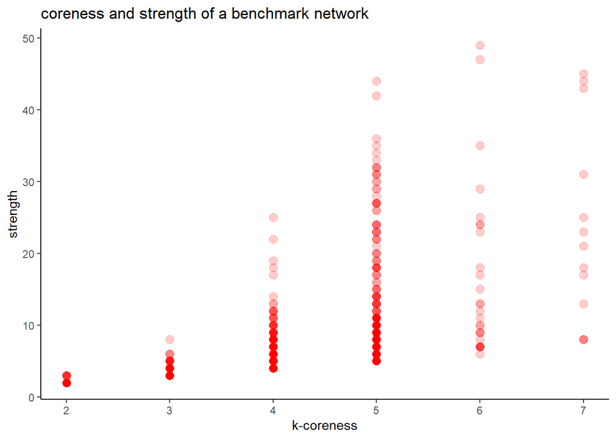

```r
sc_data <- data.frame(c = V(g)$core, s = V(g)$str)
sc_data %>% ggplot(aes(x = c, y = s))+
    geom_point(color = "red", size = 3, alpha = .2)+
    labs(title = "coreness and strength of a benchmark network", x = "k-coreness", y = "strength") +     theme_classic()
```

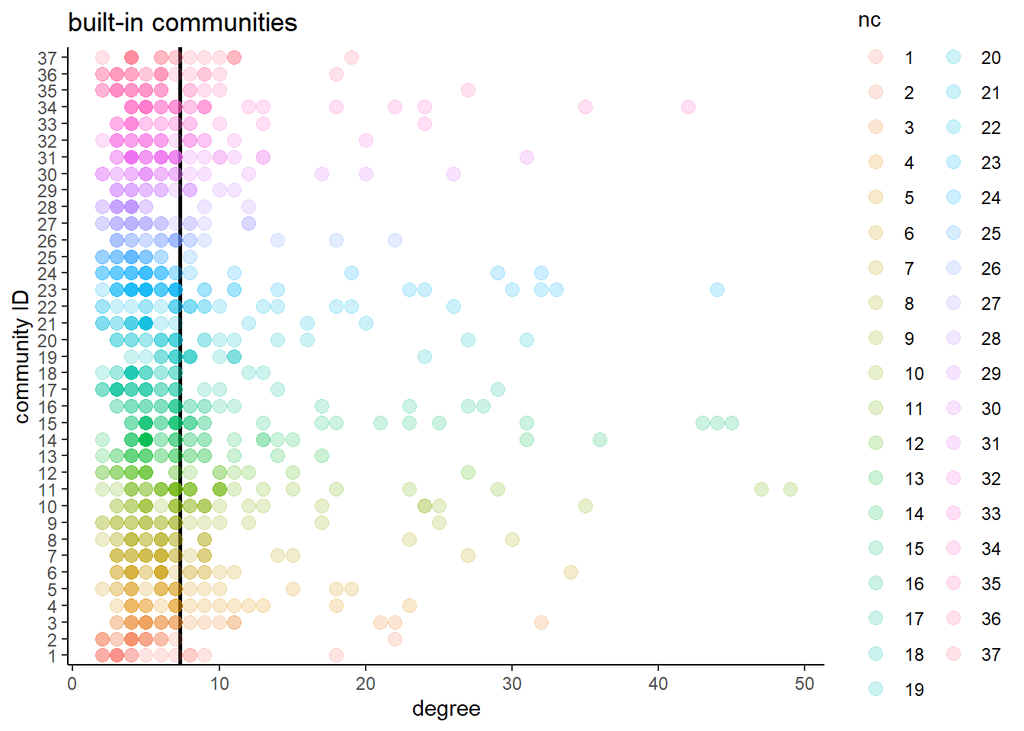

```r
dg <-  degree(g)
ncd_data <- data.frame(d = dg, nc = as.factor(V(g)$community))
ncd_data %>% ggplot(aes(x = d, y = nc, color = nc))+
  geom_vline(xintercept = mean(dg),  color = 'black', linewidth = 1, alpha = 1)+
  geom_point( size = 3, alpha = .2)+
  labs(title = "built-in communities", x = "degree", y = "community ID") +     theme_classic()
```

The family of benchmark networks can be characterized by the modularity of its built-in communities.

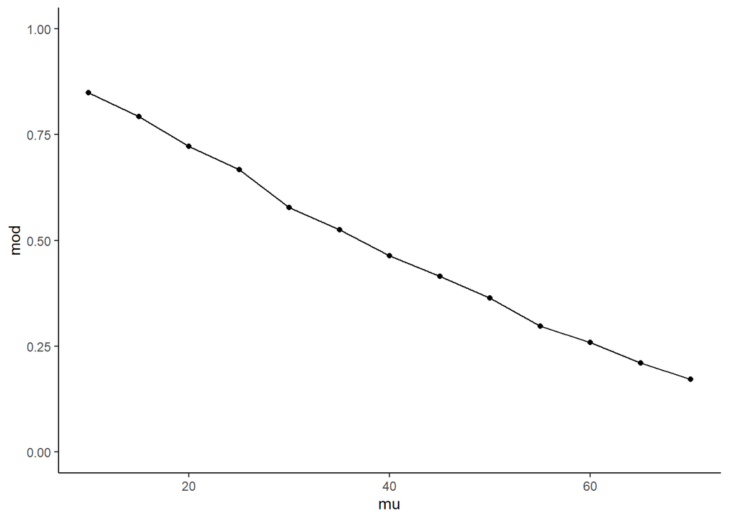

```r
mod_benchmarks <- data.frame(mu = numeric(), modularity = numeric())
for (mu in seq(10, 70, 5)) {
    g <- load_benchmark_network(mui = mu, path = path)
    mod <- modularity(g, make_clusters(g,V(g)$community )$membership )
    mod_benchmarks <- rbind(mod_benchmarks, data.frame("built-it",mu, mod))
}
mod_benchmarks %>%
  ggplot(aes(x = mu, y = mod)) +
  geom_point()+geom_line()+
  ylim(0,1) + theme_classic()
```

Methods based on modulartiy maximization are less effective with high values of $\mu$.

## 2.2 indicators

NMI NC number of communities

# 3- community definitions and community detection methods

The definition of ‘community’ in network analysis depends on the context and the researcher’s goals. for example:

1. a community is a group of nodes that are more densely connected to each other than to the rest of the network.
2. a community is group of nodes that share certain characteristics, such as having similar properties
3. a community is a group of nodes that are more likely to interact with each other than with other nodes in the network.

In this paper we will focus only on the first definition, and we will test several metohds that are consisten with that definition. Namely

- FG Fast Greedy
- IM infomap
- LP Label Propagation
- ML Multilevel (aka Louvain)
- WT walktrap

```r
find_communities <- function(g, method, verbose = FALSE) {
    if (method == "LV"){
        comms <- cluster_louvain(g, resolution = 1.0)
    } else if (method == "FG"){
        comms <- fastgreedy.community(g)
    } else if (method == "IM"){
        comms <- infomap.community(g)
    } else if (method == "LP"){
        comms <- label.propagation.community(g)
    } else if (method == "ML"){
        comms <- multilevel.community(g)
    } else if (method == "WT"){
        comms <- walktrap.community(g)
    } else {
        print("No valid method")
        stop
    }
    comms$algorithm = method
    if (verbose == TRUE) {print(paste("Community detection with ", method, "completed."))}
    return(comms)
}
```

Each method will be explored separately, in a single trial on a LFR benchmark network, highlighting the main results with the followin gfunction

```r
analyse_communities <- function(communities, mui, verbose = FALSE){
    method <- communities$algorithm
    c_membership <- communities$membership
    mod <- round(modularity (g,  c_membership+1), digits = 3)
    # need to use c_membership + 1 to handle community label 0
    nc <- length(table(c_membership))
    true_labels <- data.frame(V(g)$name, V(g)$community)
    louvain_labels <- data.frame(V(g)$name,c_membership)
    n_m_i = round( NMI(true_labels,louvain_labels)$value, 3)
    if(verbose == TRUE){
        print(paste("Communities found: ",nc))
        print(paste("Modularity: ", mod))
        print(paste("Normalized Mutual Information", n_m_i))
    }
    return(data.frame(mui, method , mod, nc, n_m_i))
}
```

all trials use the same network

```r
mui = 30
g <- load_benchmark_network(mui = mui, path = path, verbose = TRUE)
```

```
## [1] "Loaded benchmark network ./LFR_graphs/LFR/LFR_benchmark_30.gml"
## [1] "Giant component size : 1000"
## [1] "Built-in communities:  37"
## [1] "Modularity of built-in communities:  0.578"
```

## Method FG Fast Greedy

This algorithm was proposed by Clauset et al.12. It is a greedy community analysis algorithm that optimises the modularity score. This method starts with a totally non-clustered initial assignment, where each node forms a singleton community, and then computes the expected improvement of modularity for each pair of communities, chooses a community pair that gives the maximum improvement of modularity and merges them into a new community. The above procedure is repeated until no community pairs merge leads to an increase in modularity. For sparse, hierarchical, networks the algorithm runs in $O$(N log2(N)).

```r
g <- load_benchmark_network(mui = mui, path = path)
tmp_comms <- find_communities(g, method = "FG", verbose = FALSE)
results <- analyse_communities(tmp_comms, mui, verbose = TRUE)
```

```
## [1] "Communities found:  13"
## [1] "Modularity:  0.554"
## [1] "Normalized Mutual Information 0.582"
```

## Method IM infomap

This algorithm was proposed by Rosvall et al.35,36. It figures out communities by employing random walks to analyse the information flow through a network17. This algorithm starts with encoding the network into modules in a way that maximises the amount of information about the original network. Then it sends the signal to a decoder through a channel with limited capacity. The decoder tries to decode the message and to construct a set of possible candidates for the original graph. The smaller the number of candidates, the more information about the original network has been transferred. This algorithm runs in $O$(E).

```r
tmp_comms <- find_communities(g, method = "IM", verbose = FALSE)
results <- analyse_communities(tmp_comms, mui, verbose = TRUE)
```

```
## [1] "Communities found:  58"
## [1] "Modularity:  0.586"
## [1] "Normalized Mutual Information 0.872"
```

## method LP Label Propagation

This algorithm was introduced by Raghavan et al.38. It assumes that each node in the network is assigned to the same community as the majority of its neighbours. This algorithm starts with initialising a distinct label (community) for each node in the network. Then, the nodes in the network are listed in a random sequential order. Afterwards, through the sequence, each node takes the label of the majority of its neighbours. The above step will stop once each node has the same label as the majority of its neighbours. The computational complexity of label propagation algorithm is $O$(E).

```r
g <- load_benchmark_network(mui = mui, path = path)
tmp_comms <- find_communities(g, method = "IM", verbose = FALSE)
results <- analyse_communities(tmp_comms, mui, verbose = TRUE)
```

[output not shown]

## method ML Multilevel (Louvain)

This algorithm was introduced by Blondel et al.. It is a different greedy approach for optimising the modularity with respect to the Fastgreedy method. This method first assigns a different community to each node of the network, then a node is moved to the community of one of its neighbours with which it achieves the highest positive contribution to modularity. The above step is repeated for all nodes until no further improvement can be achieved. Then each community is considered as a single node on its own and the second step is repeated until there is only a single node left or when the modularity can’t be increased in a single step. The computational complexity of the Multilevel algorithm is $O$(N log N). Blondel, V. D., Guillaume, J.-L., Lambiotte, R. & Lefebvre, E. Fast unfolding of communities in large networks. Journal of Statistical Mechanics: Theory and Experiment 2008, P10008 (2008).

```r
g <- load_benchmark_network(mui = mui, path = path)
tmp_comms <- find_communities(g, method = "ML", verbose = FALSE)
results <- analyse_communities(tmp_comms, mui, verbose = TRUE)
```

```
## [1] "Communities found:  23"
## [1] "Modularity:  0.592"
## [1] "Normalized Mutual Information 0.765"
```

## method WT walktrap

This algorithm was proposed by Pon & Latapy. It is a hierarchical clustering algorithm. The basic idea of this method is that short distance random walks tend to stay in the same community. Starting from a totally non-clustered partition, the distances between all adjacent nodes are computed. Then, two adjacent communities are chosen, they are merged into a new one and the distances between communities are updated. This step is repeated (N − 1) times, thus the computational complexity of this algorithm is (E N2). For sparse networks the computational complexity is $O$(N2 log(N)

```r
g <- load_benchmark_network(mui = mui, path = path)
tmp_comms <- find_communities(g, method = "WT", verbose = FALSE)
results <- analyse_communities(tmp_comms, mui, verbose = TRUE)
```

```
## [1] "Communities found:  46"
## [1] "Modularity:  0.569"
## [1] "Normalized Mutual Information 0.769"
```

# 4- performance of 6 CD methods on LFR benchmark networks (repeated trials)

```r
data_to_plot<- read_csv('results_n_trials.csv')
```

## performance of different methods over repeated trials: modularity

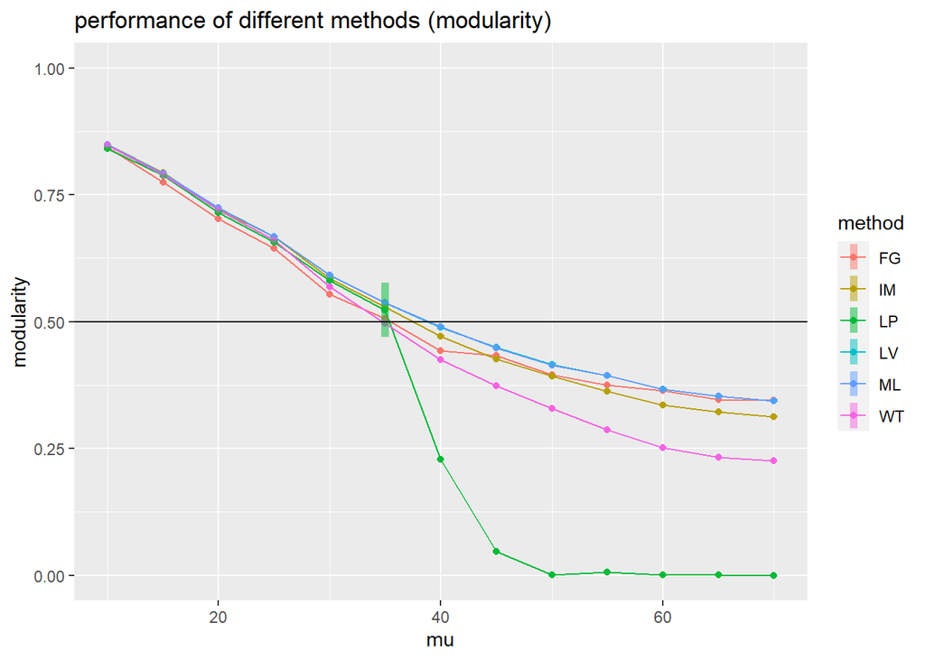

```r
data_to_plot %>% group_by(method, mui) %>%
    summarise(m = mean(mod), sd = sd(mod) ) %>%
    ggplot(aes(x = mui, y = m)) +
    geom_line(aes(color = method)) +
    geom_point(aes(color = method)) +
    geom_linerange(aes(ymin =m-sd, ymax = m + sd, color = method), linewidth = 2, alpha = 0.5)+
    ylim(0,1) + geom_hline(yintercept = 0.5)+
    labs(title = "performance of different methods (modularity)", y = "modularity", x = "mu") +
    theme_gray()
```

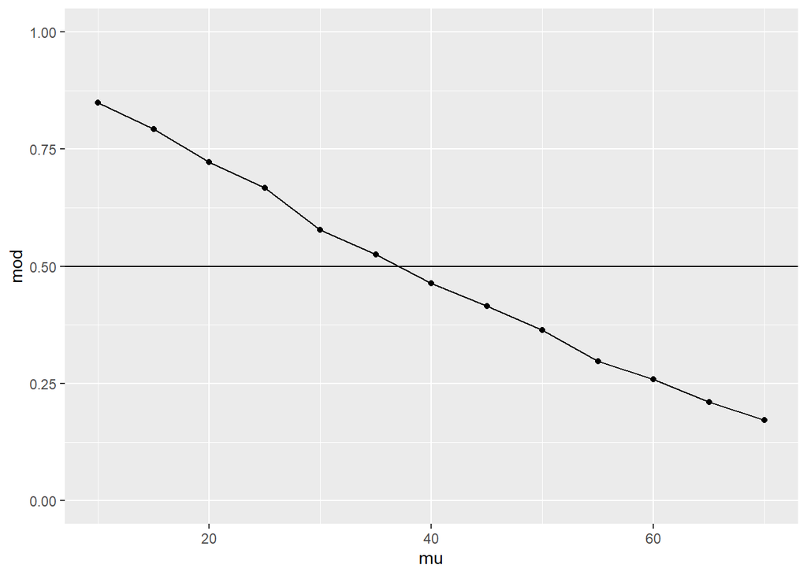

```r
mod_benchmarks %>%
  ggplot(aes(x = mu, y = mod)) +
  geom_point()+geom_line()+
  ylim(0,1) +     geom_hline(yintercept = 0.5)+
    theme_gray()
```